# Scoring model for Default of Credit Card Clients

Julita Cichońska

2021-03-07

# Intro

Our goal is to build a scoring model to assess probability of default of credit card clients. We are going to use a dataset which can be found here:

https://archive.ics.uci.edu/ml/datasets/default+of+credit+card+clients.

## Features Description

**Source reference**

This research employed a binary variable, default payment (Yes = 1, No = 0), as the response variable. This study reviewed the literature and used the following 23 variables as explanatory variables:

X1: Amount of the given credit (NT dollar): it includes both the individual consumer credit and his/her family (supplementary) credit.

X2: Gender (1 = male; 2 = female).

X3: Education (1 = graduate school; 2 = university; 3 = high school; 4 = others).

X4: Marital status (1 = married; 2 = single; 3 = others).

X5: Age (year).

X6 - X11: History of past payment. We tracked the past monthly payment records (from April to September, 2005) as follows: X6 = the repayment status in September, 2005; X7 = the repayment status in August, 2005; . . .;X11 = the repayment status in April, 2005. The measurement scale for the repayment status is: -1 = pay duly; 1 = payment delay for one month; 2 = payment delay for two months; . . .; 8 = payment delay for eight months; 9 = payment delay for nine months and above.

X12-X17: Amount of bill statement (NT dollar). X12 = amount of bill statement in September, 2005; X13 = amount of bill statement in August, 2005; . . .; X17 = amount of bill statement in April, 2005.

X18-X23: Amount of previous payment (NT dollar). X18 = amount paid in September, 2005; X19 = amount paid in August, 2005; . . .;X23 = amount paid in April, 2005.

## Data Loading

```r
library(readxl)
library(dplyr)
library(ggplot2)
library(purrr)
library(corrplot)
library(scorecard)
library(stringr)
library(kableExtra)
library(gridExtra)
source('utility_functions.R')
```

Firstly, we are going to load the dataset from xls file.

```r
df_raw <- read_excel(path = 'default of credit card clients.xls', col_names = TRUE, skip = 1)

head(df_raw, 10) %>%
  kable() %>%
  kable_styling(bootstrap_options = "hover") %>%
  scroll_box(width = "800px", height = "400px")
```

| ID | LIMIT_BAL | SEX | EDUCATION | MARRIAGE | AGE | PAY_0 | PAY_2 | PAY_3 | PAY_4 | PAY_5 | PAY_6 | BILL_AMT1 | BILL_AMT2 | BILL_AMT3 | BILL_AMT4 | BILL_AMT5 | BILL_AMT6 | PAY_AMT1 | PAY_AMT2 | PAY_AMT3 | PAY_AMT4 | PAY_AMT5 | PAY_AMT6 | default payment next month |
| --- | --- | --- | --- | --- | --- | --- | --- | --- | --- | --- | --- | --- | --- | --- | --- | --- | --- | --- | --- | --- | --- | --- | --- | --- |
| 1 | 20000 | 2 | 2 | 1 | 24 | 2 | 2 | -1 | -1 | -2 | -2 | 3913 | 3102 | 689 | 0 | 0 | 0 | 0 | 689 | 0 | 0 | 0 | 0 | 1 |
| 2 | 120000 | 2 | 2 | 2 | 26 | -1 | 2 | 0 | 0 | 0 | 2 | 2682 | 1725 | 2682 | 3272 | 3455 | 3261 | 0 | 1000 | 1000 | 1000 | 0 | 2000 | 1 |
| 3 | 90000 | 2 | 2 | 2 | 34 | 0 | 0 | 0 | 0 | 0 | 0 | 29239 | 14027 | 13559 | 14331 | 14948 | 15549 | 1518 | 1500 | 1000 | 1000 | 1000 | 5000 | 0 |
| 4 | 50000 | 2 | 2 | 1 | 37 | 0 | 0 | 0 | 0 | 0 | 0 | 46990 | 48233 | 49291 | 28314 | 28959 | 29547 | 2000 | 2019 | 1200 | 1100 | 1069 | 1000 | 0 |
| 5 | 50000 | 1 | 2 | 1 | 57 | -1 | 0 | -1 | 0 | 0 | 0 | 8617 | 5670 | 35835 | 20940 | 19146 | 19131 | 2000 | 36681 | 10000 | 9000 | 689 | 679 | 0 |
| 6 | 50000 | 1 | 1 | 2 | 37 | 0 | 0 | 0 | 0 | 0 | 0 | 64400 | 57069 | 57608 | 19394 | 19619 | 20024 | 2500 | 1815 | 657 | 1000 | 1000 | 800 | 0 |
| 7 | 500000 | 1 | 1 | 2 | 29 | 0 | 0 | 0 | 0 | 0 | 0 | 367965 | 412023 | 445007 | 542653 | 483003 | 473944 | 55000 | 40000 | 38000 | 20239 | 13750 | 13770 | 0 |
| 8 | 100000 | 2 | 2 | 2 | 23 | 0 | -1 | -1 | 0 | 0 | -1 | 11876 | 380 | 601 | 221 | -159 | 567 | 380 | 601 | 0 | 581 | 1687 | 1542 | 0 |
| 9 | 140000 | 2 | 3 | 1 | 28 | 0 | 0 | 2 | 0 | 0 | 0 | 11285 | 14096 | 12108 | 12211 | 11793 | 3719 | 3329 | 0 | 432 | 1000 | 1000 | 1000 | 0 |
| 10 | 20000 | 1 | 3 | 2 | 35 | -2 | -2 | -2 | -2 | -1 | -1 | 0 | 0 | 0 | 0 | 13007 | 13912 | 0 | 0 | 0 | 13007 | 1122 | 0 | 0 |

Next we need to change name of response variable and drop unnecesary column.

```r
colnames(df_raw)[25] <- 'DEFAULT'
df_raw$ID <- NULL
```

# Preprocessing

## Recoding

We will focus mainly on categorical features: SEX, EDUCATION and MARRIAGE. We will decode those features to original values, as we will transform variables with Weight of Evidence method later on.

```r
df <- df_raw %>% mutate(
                    SEX = as.factor(case_when(SEX == 1 ~ 'male',
                                              SEX == 2 ~ 'female')),
                    EDUCATION = as.factor(case_when(EDUCATION == 1 ~'graduate school',
                                                    EDUCATION == 2 ~'university',
                                                    EDUCATION == 3 ~'high school',
                                                    EDUCATION == 4 ~'others')),
                    MARRIAGE = as.factor(case_when(MARRIAGE == 1 ~ 'married',
                                                   MARRIAGE == 2 ~ 'single',
                                                   MARRIAGE == 3 ~ 'others')))
```

## Dataset review

```r
featuresReview(df) %>% kable() %>%
  kable_styling(bootstrap_options = "hover") %>%
  scroll_box(height = "400px")
```

| names | class | type | n_unique | n_NA | n_0 | mean | min | median | max |
| --- | --- | --- | --- | --- | --- | --- | --- | --- | --- |
| LIMIT_BAL | numeric | double | 81 | 0 | 0 | 167484.32 | 10000 | 140000.0 | 1000000 |
| SEX | factor | integer | 2 | 0 | NA | NA | NA | NA | NA |
| EDUCATION | factor | integer | 5 | 345 | NA | NA | NA | NA | NA |
| MARRIAGE | factor | integer | 4 | 54 | NA | NA | NA | NA | NA |
| AGE | numeric | double | 56 | 0 | 0 | 35.49 | 21 | 34.0 | 79 |
| PAY_0 | numeric | double | 11 | 0 | 14737 | -0.02 | -2 | 0.0 | 8 |
| PAY_2 | numeric | double | 11 | 0 | 15730 | -0.13 | -2 | 0.0 | 8 |
| PAY_3 | numeric | double | 11 | 0 | 15764 | -0.17 | -2 | 0.0 | 8 |
| PAY_4 | numeric | double | 11 | 0 | 16455 | -0.22 | -2 | 0.0 | 8 |
| PAY_5 | numeric | double | 10 | 0 | 16947 | -0.27 | -2 | 0.0 | 8 |
| PAY_6 | numeric | double | 10 | 0 | 16286 | -0.29 | -2 | 0.0 | 8 |
| BILL_AMT1 | numeric | double | 22723 | 0 | 2008 | 51223.33 | -165580 | 22381.5 | 964511 |
| BILL_AMT2 | numeric | double | 22346 | 0 | 2506 | 49179.08 | -69777 | 21200.0 | 983931 |
| BILL_AMT3 | numeric | double | 22026 | 0 | 2870 | 47013.15 | -157264 | 20088.5 | 1664089 |
| BILL_AMT4 | numeric | double | 21548 | 0 | 3195 | 43262.95 | -170000 | 19052.0 | 891586 |
| BILL_AMT5 | numeric | double | 21010 | 0 | 3506 | 40311.40 | -81334 | 18104.5 | 927171 |
| BILL_AMT6 | numeric | double | 20604 | 0 | 4020 | 38871.76 | -339603 | 17071.0 | 961664 |
| PAY_AMT1 | numeric | double | 7943 | 0 | 5249 | 5663.58 | 0 | 2100.0 | 873552 |
| PAY_AMT2 | numeric | double | 7899 | 0 | 5396 | 5921.16 | 0 | 2009.0 | 1684259 |
| PAY_AMT3 | numeric | double | 7518 | 0 | 5968 | 5225.68 | 0 | 1800.0 | 896040 |
| PAY_AMT4 | numeric | double | 6937 | 0 | 6408 | 4826.08 | 0 | 1500.0 | 621000 |
| PAY_AMT5 | numeric | double | 6897 | 0 | 6703 | 4799.39 | 0 | 1500.0 | 426529 |
| PAY_AMT6 | numeric | double | 6939 | 0 | 7173 | 5215.50 | 0 | 1500.0 | 528666 |
| DEFAULT | numeric | double | 2 | 0 | 23364 | 0.22 | 0 | 0.0 | 1 |

## Missing Data Imputation

As we can see in the summary above, there are missing values in variables EDUCATION and MARRIAGE.

```r
imputeFactor <- function(v_col, string_imp = 'missing'){
  levels(v_col) <- c(levels(v_col) , string_imp)
  v_col[is.na(v_col)] <- string_imp
  v_col
}

df$EDUCATION <- imputeFactor(df$EDUCATION)
df$MARRIAGE <- imputeFactor(df$MARRIAGE)
```

## Variables Types

Finally, we need to cast some variables to integers.

```r
df <- df %>% mutate(across(starts_with("PAY")&!contains("AMT"), as.integer))
df <- df %>% mutate(DEFAULT = as.integer(DEFAULT))
```

## Learn Test Split

Let’s split data set into two parts: learn set and test set in proportion 3:1.

```r
set.seed(2021)
n_obs <- dim(df)[1]
idx <- sample(1:n_obs, size = 0.75*n_obs, replace = FALSE)

df_learn <- df[idx,]
df_test <- df[-idx,]
```

Checking Default Rate after split - need to be roughly equal.

```r
data.frame(set = c('learn', 'test'),
                   default_rate = rbind(mean(df_learn$DEFAULT),mean(df_test$DEFAULT))
) %>% kable() %>% kable_styling(full_width = F)
```

| set | default_rate |
| --- | --- |
| learn | 0.2195111 |
| test | 0.2262667 |

# Features Analysis

## Distributions

Selecting names of variables to plot

```r
df_learn_fct <- df_learn %>% select_if(funs(is.factor(.)||is.integer(.)))
df_learn_cont <- df_learn %>% select_if(funs(!is.factor(.)&!is.integer(.)))
```

## Categorical and discrete variables

Plotting distributions of categorical and descrete variables using utility function plotFactor (utility_functions.R)

```r
plots_list <- plotFactor(df_learn_fct, colnames(df_learn_fct))
for (i in seq_along(plots_list)){
  plots_list[[i]] <- list(plots_list[[i]], colnames(df_learn_fct)[i])}
```

```r
for (i in seq_along(plots_list)){
  tmp <- plots_list[[i]]
  cat('###', tmp[[2]], " \n")
  print(tmp[[1]])
  cat('\n\n')}
```

### SEX

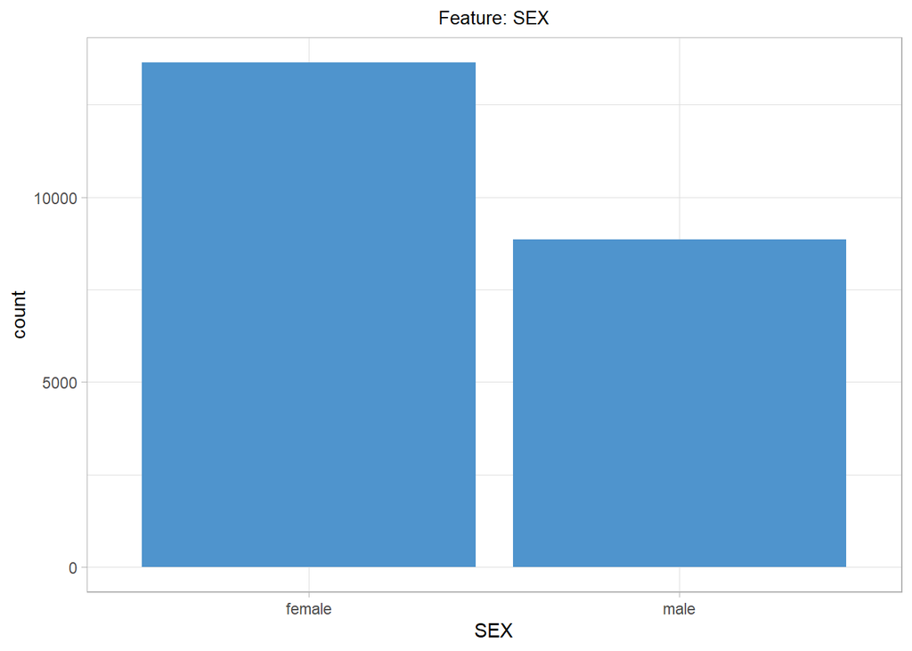

### EDUCATION

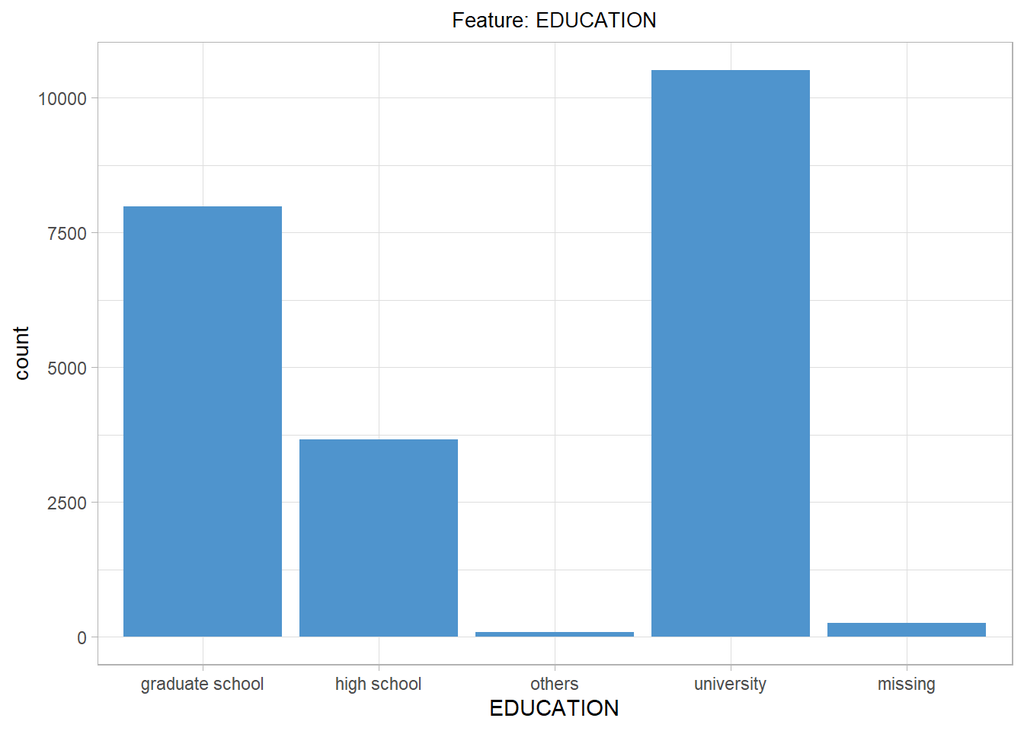

### MARRIAGE

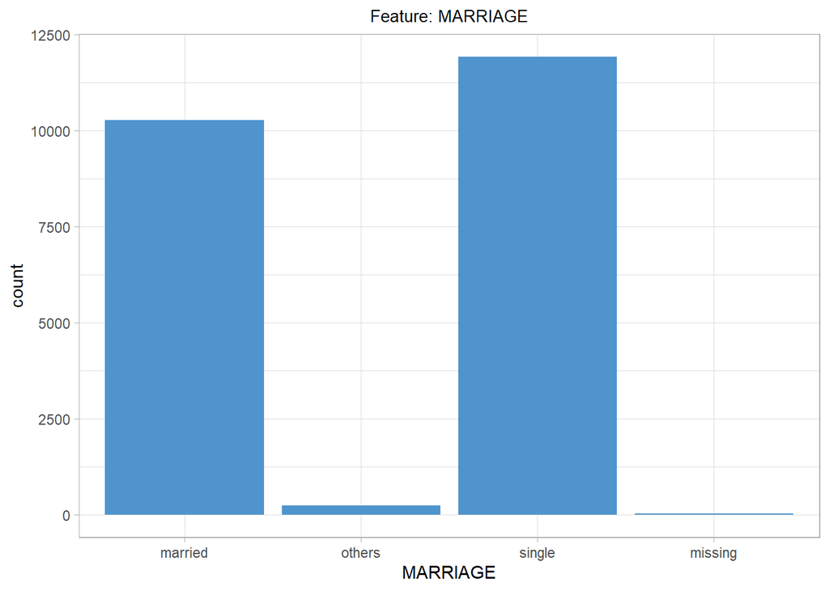

### PAY_0

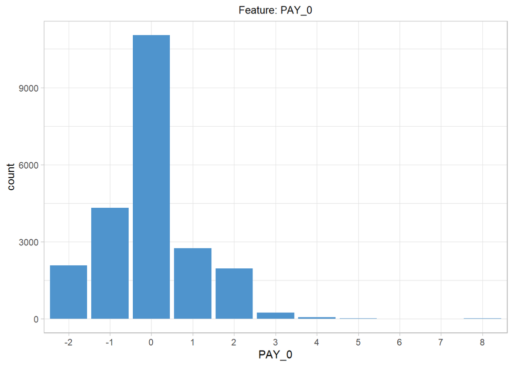

### PAY_2

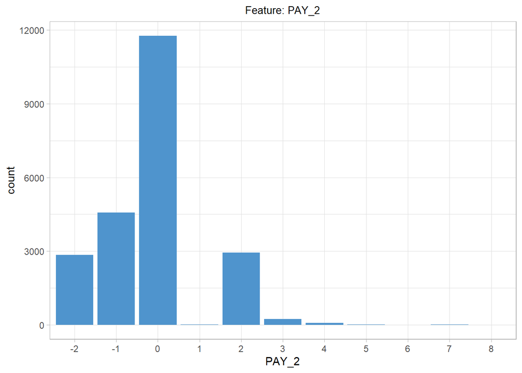

### PAY_3

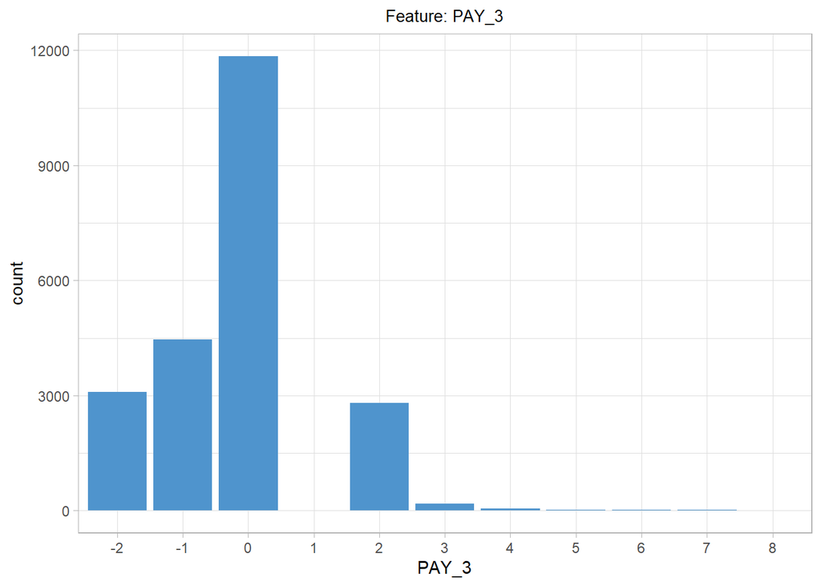

### PAY_4

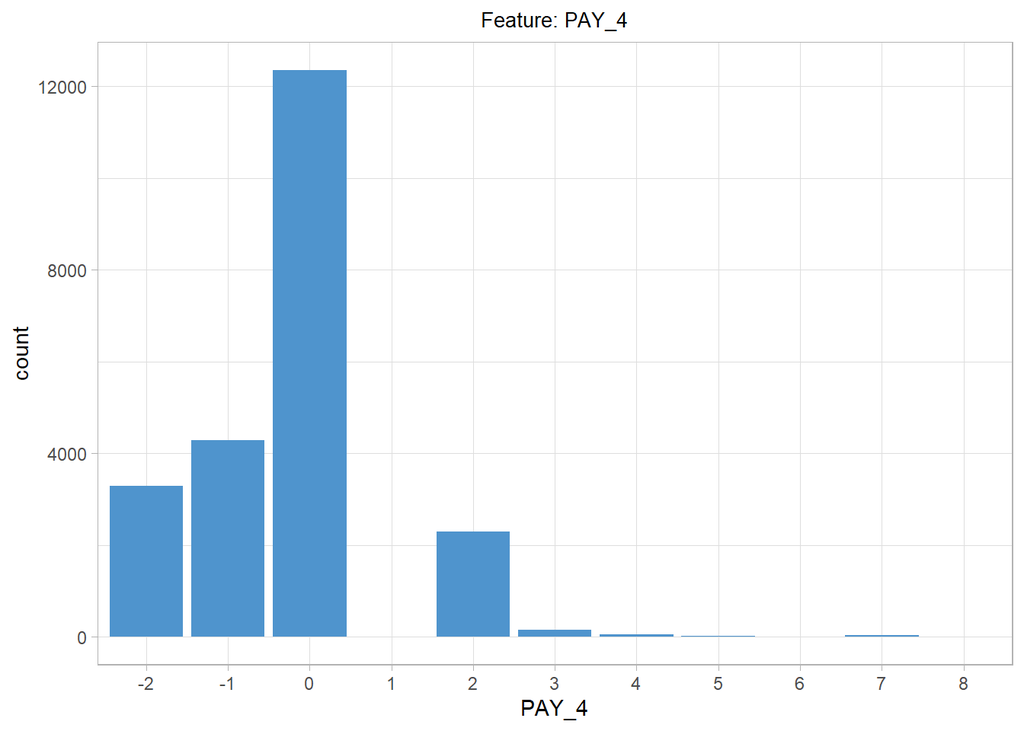

### PAY_5

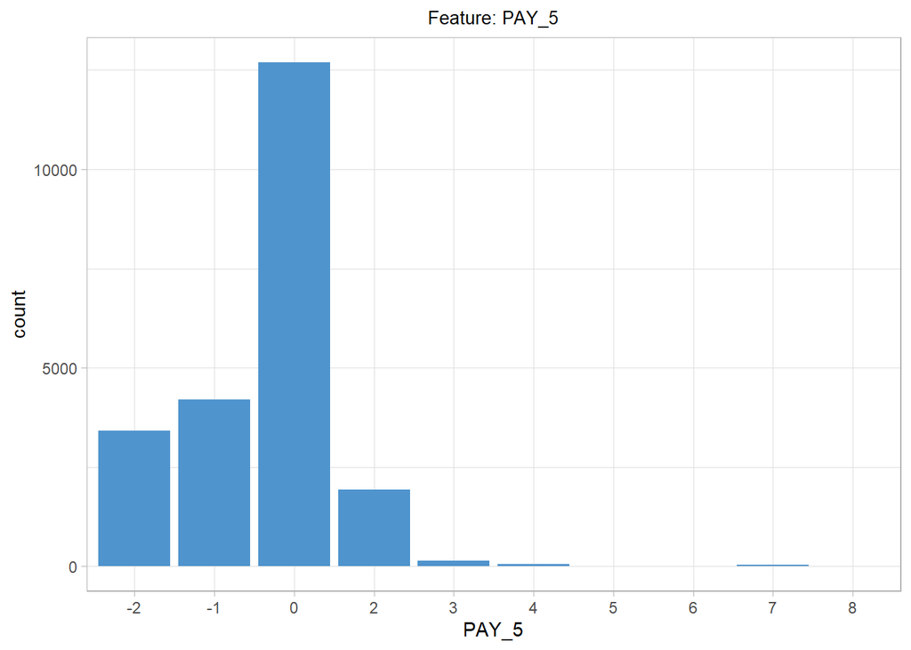

### PAY_6

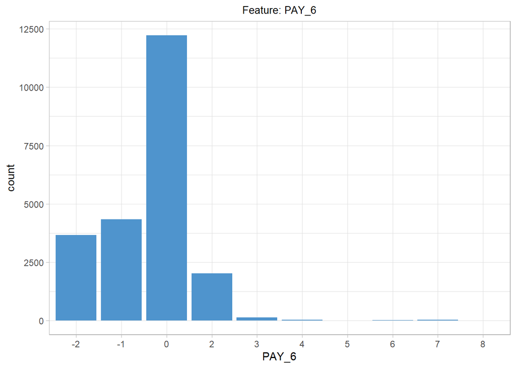

### DEFAULT

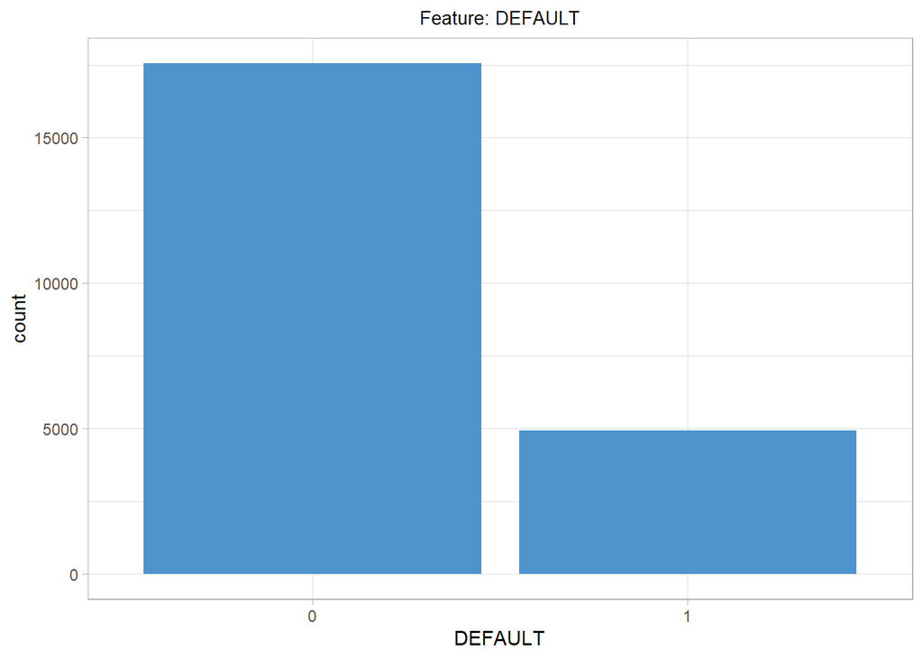

## Continuous variables

Plotting distributions of continuous variables using utility function plotHistogram (utility_functions.R)

```r
plots_list <- plotHistogram(df_learn_cont, colnames(df_learn_cont) )
for (i in seq_along(plots_list)){
  plots_list[[i]] <- list(plots_list[[i]], colnames(df_learn_cont)[i])}
```

```r
for (i in seq_along(plots_list)){
  tmp <- plots_list[[i]]
  cat('###', tmp[[2]], " \n")
  print(tmp[[1]])
  cat('\n\n')}
```

### LIMIT_BAL

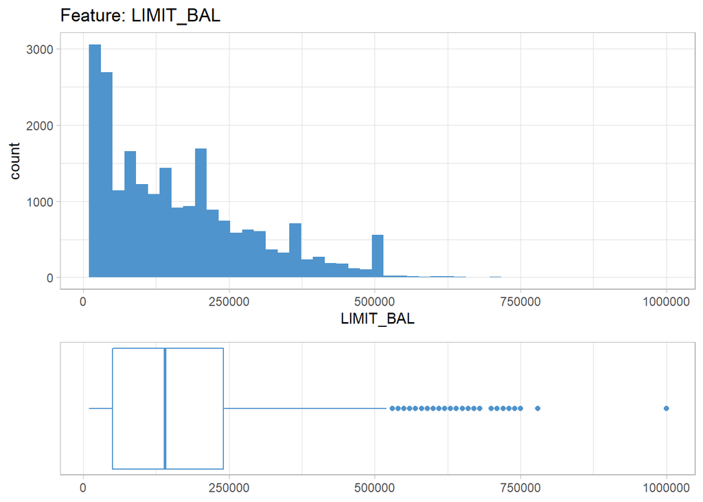

### AGE

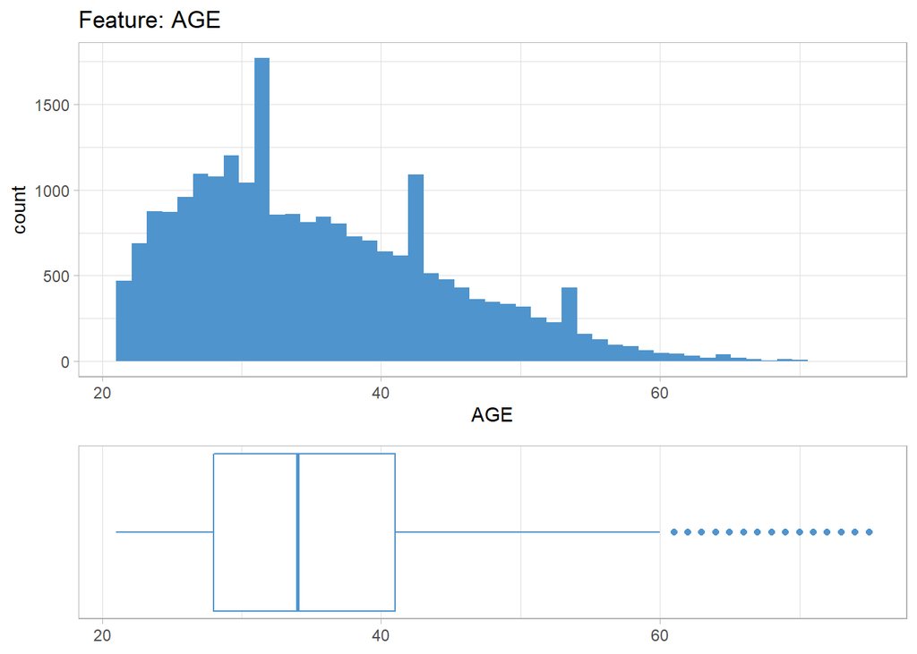

### BILL_AMT1

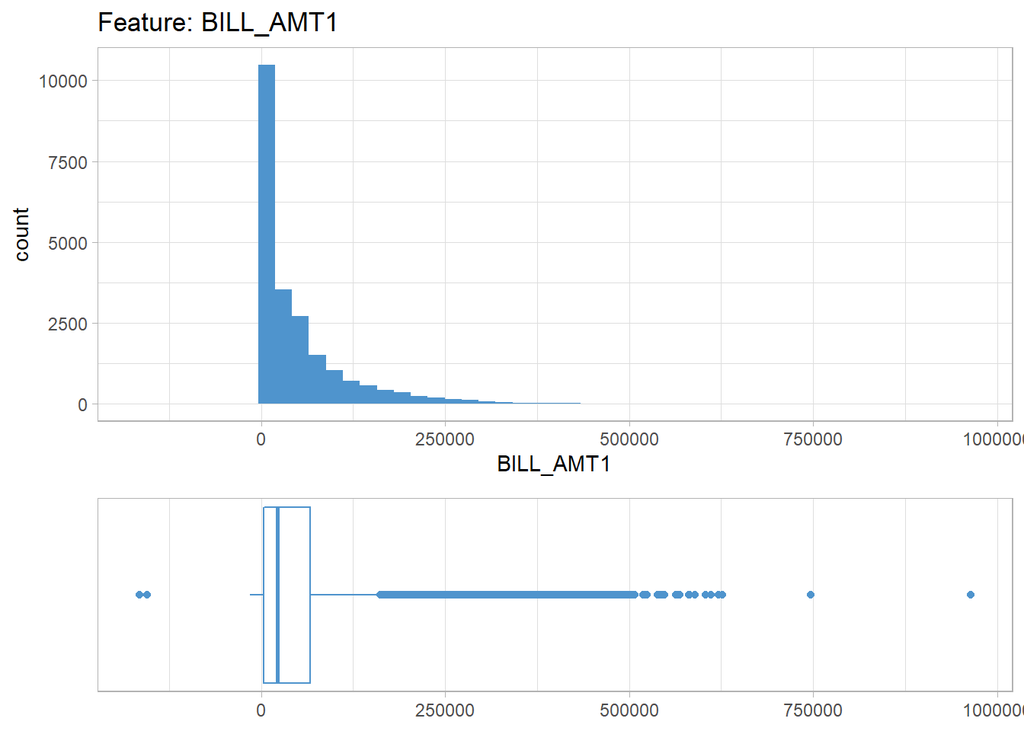

### BILL_AMT2

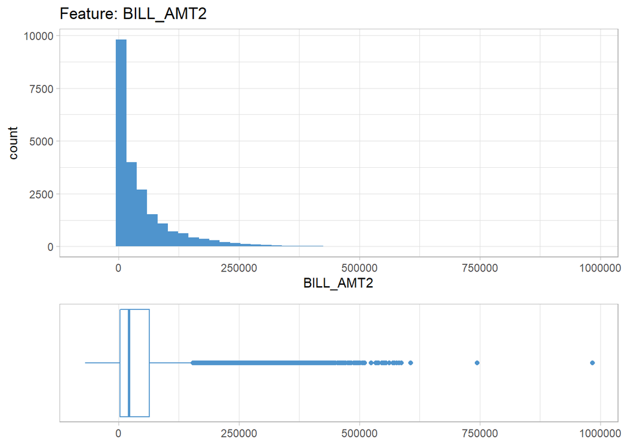

### BILL_AMT3

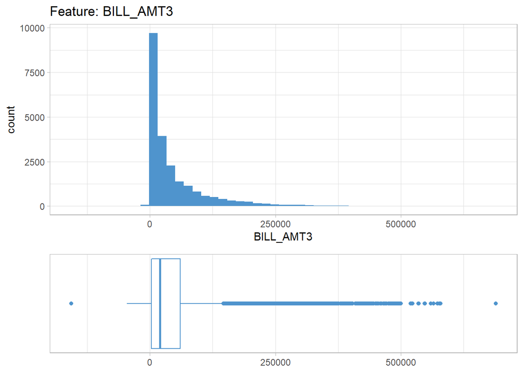

### BILL_AMT4

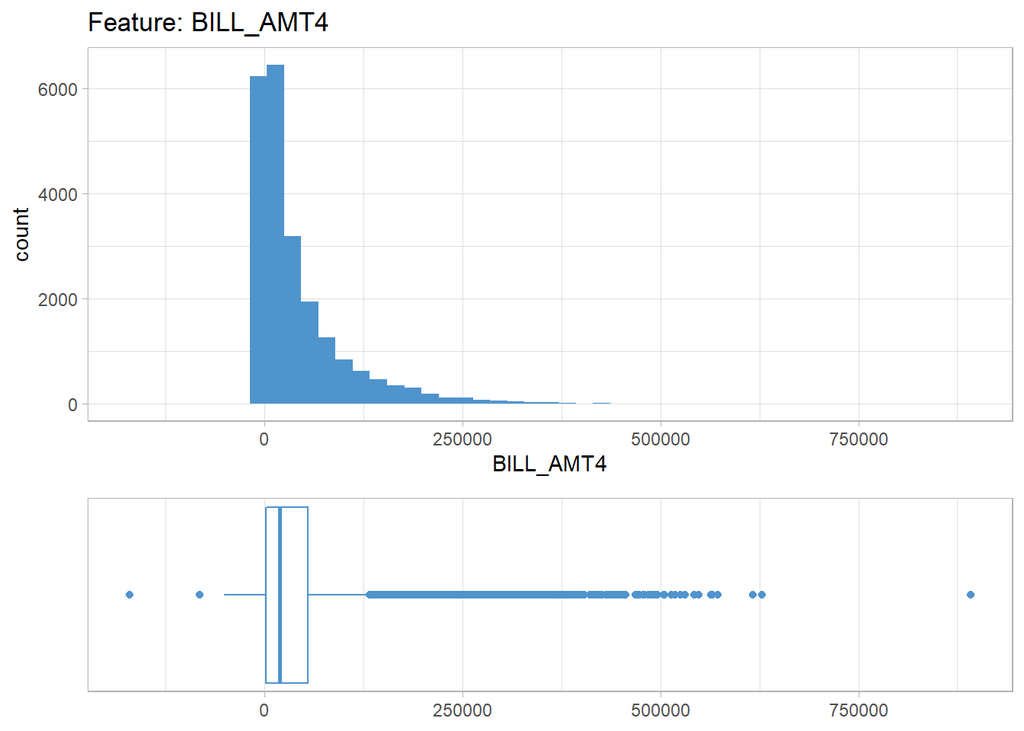

### BILL_AMT5

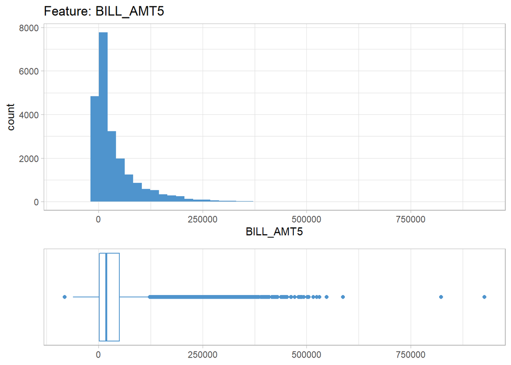

### BILL_AMT6

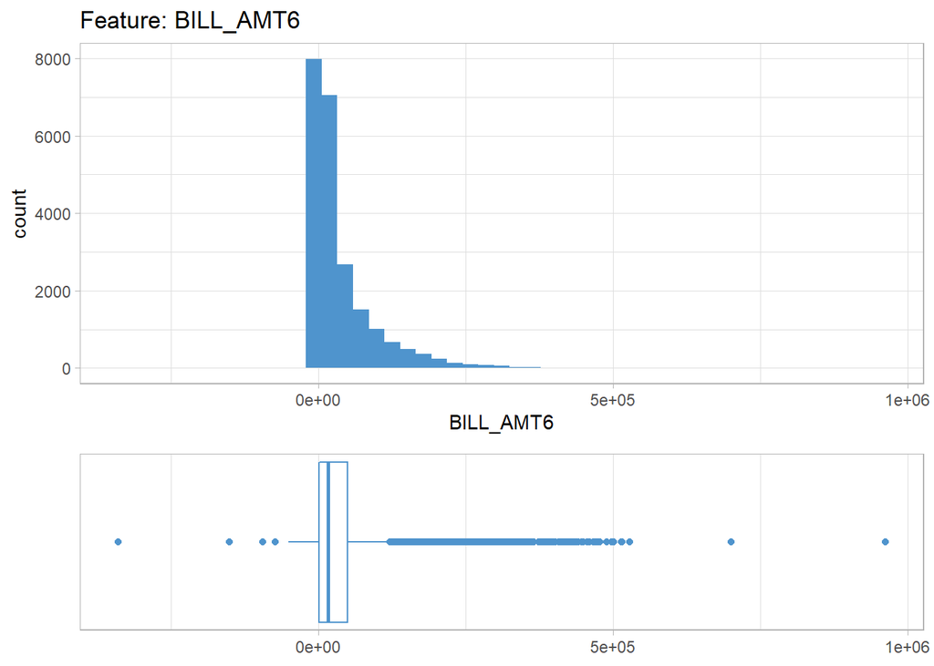

### PAY_AMT1

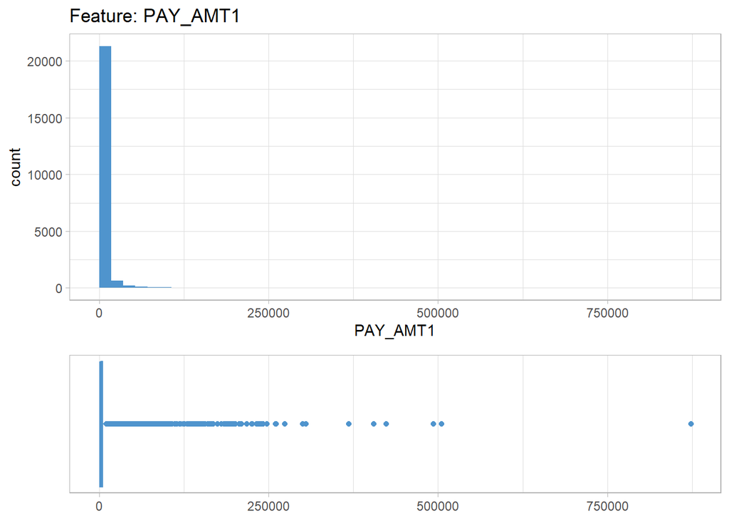

### PAY_AMT2

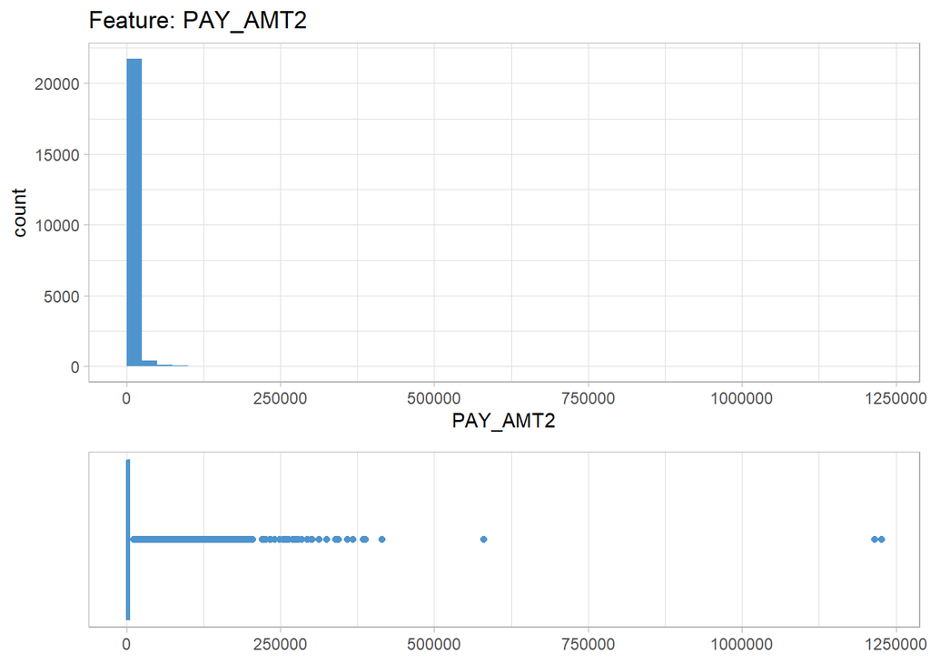

### PAY_AMT3

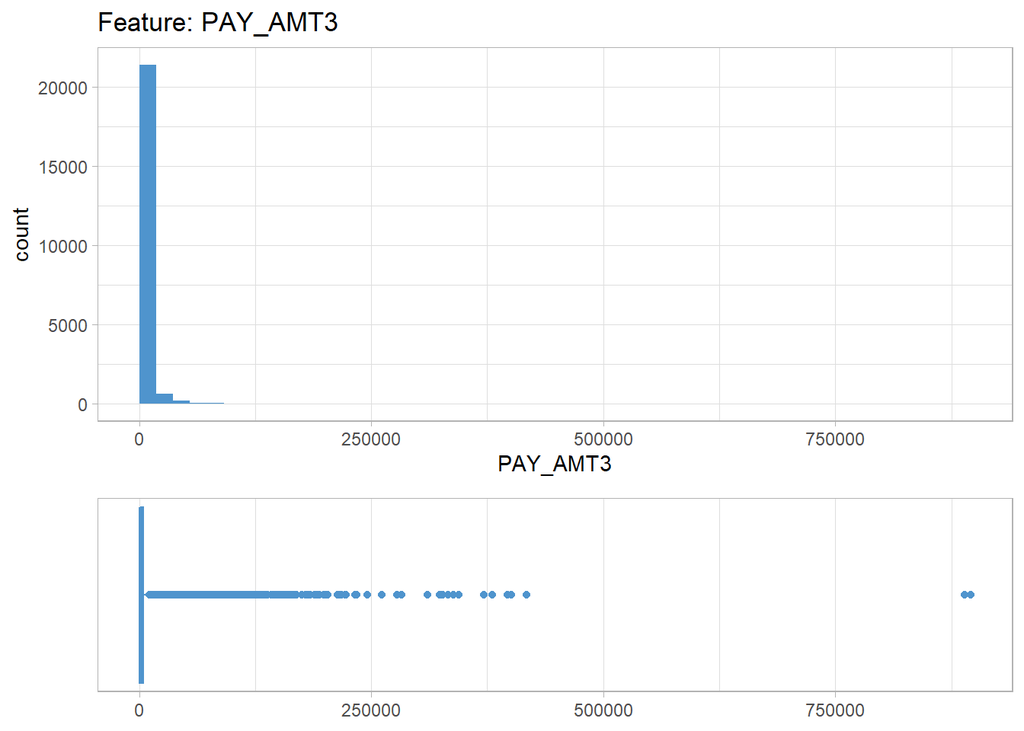

### PAY_AMT4

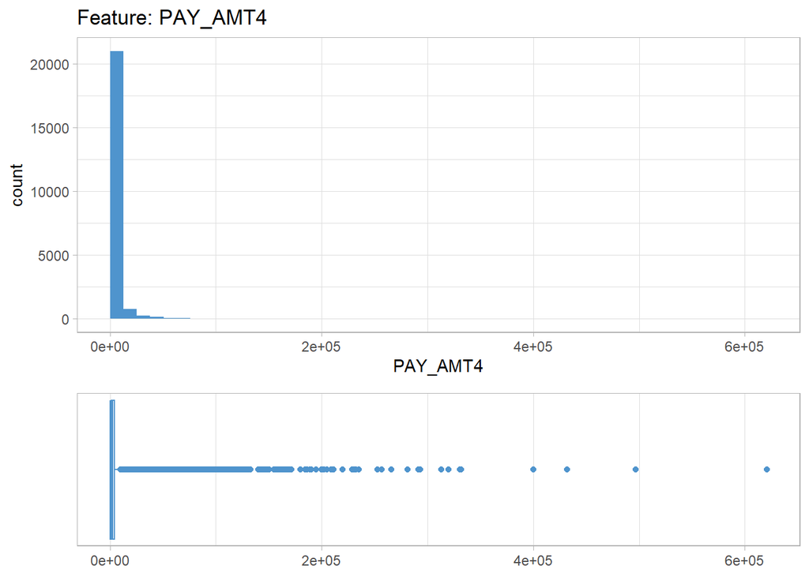

### PAY_AMT5

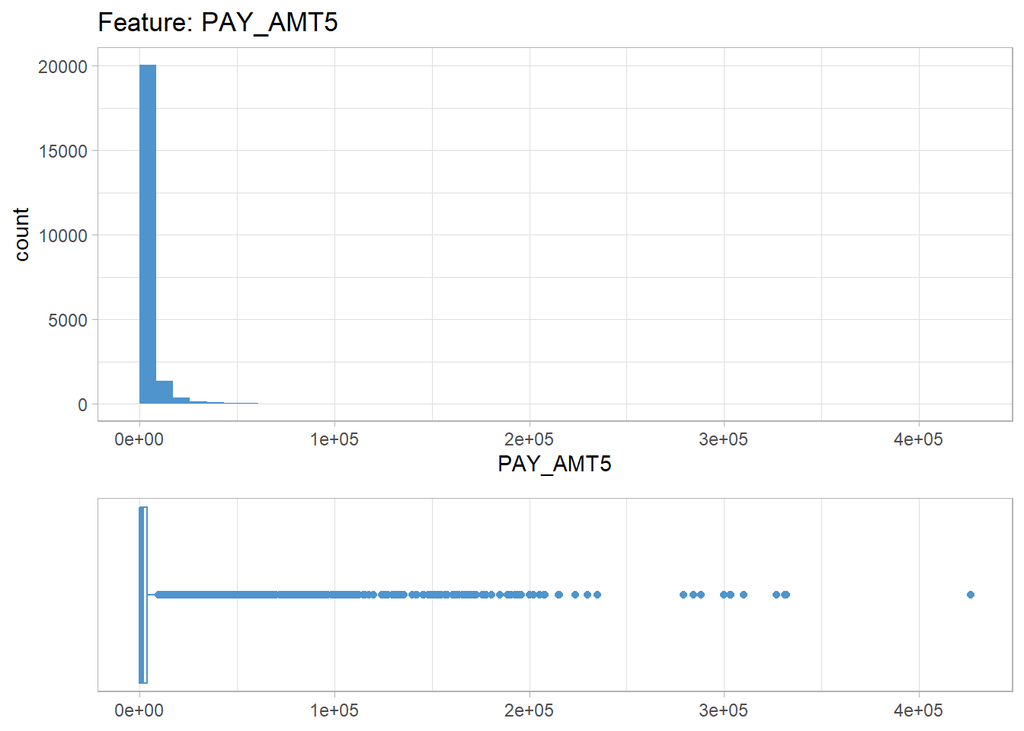

### PAY_AMT6

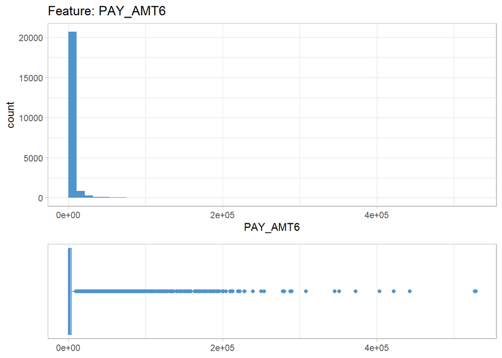

## Correlations

In order to examine possible correlations between variables we are selecting numerical variables and calculating correlation matrix. To visualize correlation matrix we are using corrplot with hierachical clustering to recognize groups of most correlated variables.

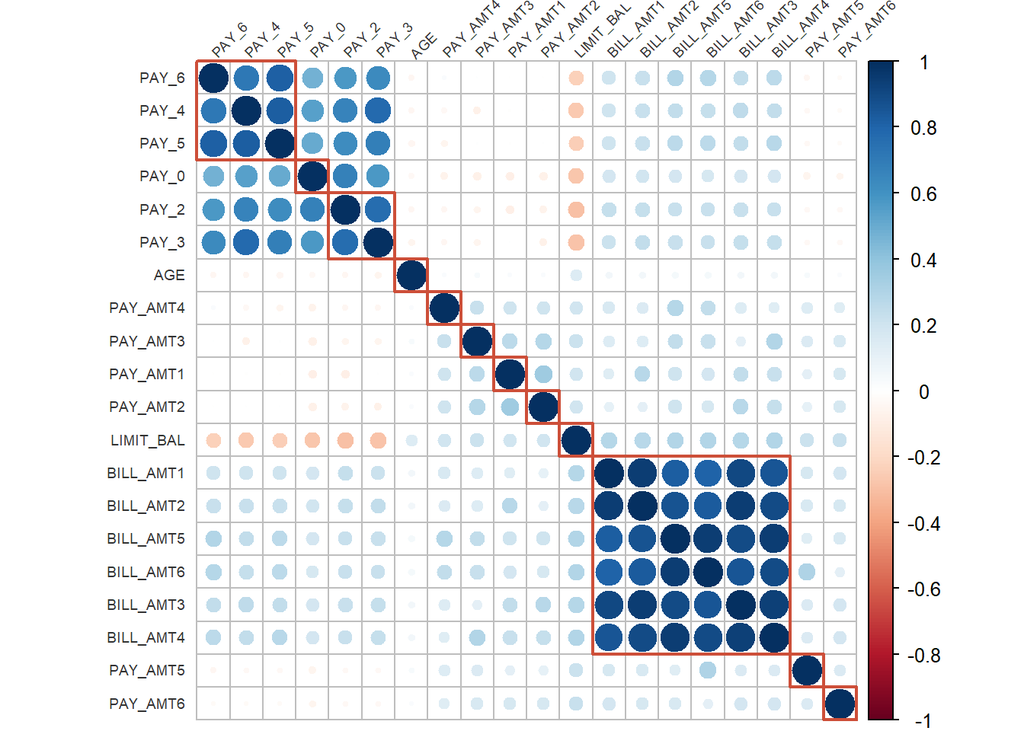

```r
df_learn_num <- df_learn %>% select_if(is.numeric) %>% select(-DEFAULT)

cor_M <- cor(df_learn_num)

cor_plot <- corrplot(corr = cor_M,
                     method = 'circle',
                     type = 'full',
                     order = 'hclust',
                     hclust.method = 'complete',
                     addrect = 12,
                     rect.col = 'tomato3',
                     tl.col = 'grey20',
                     tl.cex = 0.6,
                     tl.srt = 45)
```

Clusters extraction: plotting cluster dendrogram with parameters matching hclust in corrplot (distance of 1-cor_M) and cutting dendrogram to specific number of clusters.

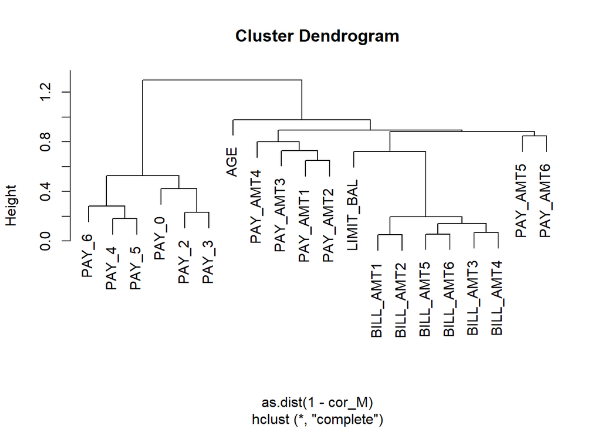

```r
clust_obj <- hclust(as.dist(1-cor_M))

plot(clust_obj)
```

```r
clust_cut <- data.frame(cluster = cutree(clust_obj, k = 12)) %>% mutate(variable = rownames(.))
```

## Feature selection

Finally, we are selecting one representative from every cluster based on information value.

```r
df_iv <- data.frame(scorecard::iv(df_learn %>% select_if(is.numeric), 'DEFAULT'))

df_merge <- merge(clust_cut, df_iv, by = 'variable')

df_merge %>%
  arrange(cluster, -info_value) %>%
  kable() %>%
  kable_styling(full_width = F, bootstrap_options = "hover") %>% scroll_box(height = '300px', width = '300px')
```

| variable | cluster | info_value |
| --- | --- | --- |
| LIMIT_BAL | 1 | 0.2161446 |
| AGE | 2 | 0.0290124 |
| PAY_0 | 3 | 0.9172402 |
| PAY_2 | 4 | 0.5848601 |
| PAY_3 | 4 | 0.4346251 |
| PAY_4 | 5 | 0.3911591 |
| PAY_5 | 5 | 0.3633789 |
| PAY_6 | 5 | 0.3079972 |
| BILL_AMT6 | 6 | 0.1809612 |
| BILL_AMT5 | 6 | 0.1682050 |
| BILL_AMT4 | 6 | 0.1602651 |
| BILL_AMT3 | 6 | 0.1476496 |
| BILL_AMT2 | 6 | 0.1381897 |
| BILL_AMT1 | 6 | 0.1263152 |
| PAY_AMT1 | 7 | 0.3541733 |
| PAY_AMT2 | 8 | 0.3336457 |
| PAY_AMT3 | 9 | 0.3522851 |
| PAY_AMT4 | 10 | 0.3444778 |
| PAY_AMT5 | 11 | 0.3591672 |
| PAY_AMT6 | 12 | 0.3515896 |

```r
df_sel_numeric <- df_merge %>%
  group_by(cluster) %>%
  arrange(-info_value) %>%
  top_n(1) %>% arrange(cluster)

names_sel_num <- df_sel_numeric %>% pull(variable)
```

# WoE transformation

Preparing data frame for Weight of Evidence tranformation

```r
names_sel_all <- c(names_sel_num, names(df_learn_fct),  'DEFAULT')

df_woe <- df_learn %>% select(all_of(names_sel_all))

df_woebin <- scorecard::woebin(df_woe, 'DEFAULT')
```

```
## [INFO] creating woe binning ...
```

```r
df_learn_woe <- scorecard::woebin_ply(df_woe, bins = df_woebin )
```

```
## [INFO] converting into woe values ...
```

## WoEPlots

```r
plots_list <- plotWoe(df_woebin, names(df_woebin) )
for (i in seq_along(plots_list)){
  plots_list[[i]] <- list(plots_list[[i]], names(df_woebin)[i])}
```

```r
for (i in seq_along(plots_list)){
  tmp <- plots_list[[i]]
  cat('###', tmp[[2]], " \n")
  print(tmp[[1]])
  cat('\n\n')}
```

### LIMIT_BAL

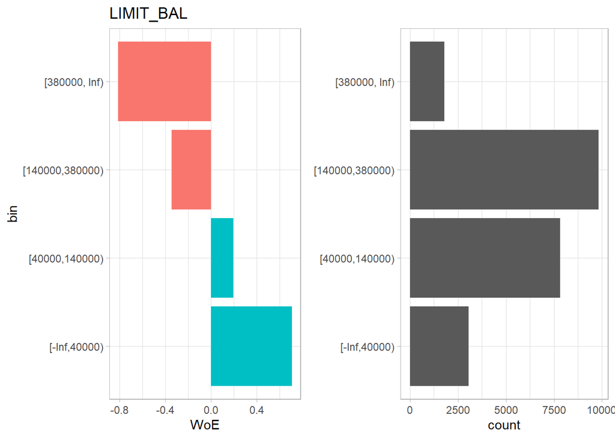

### AGE

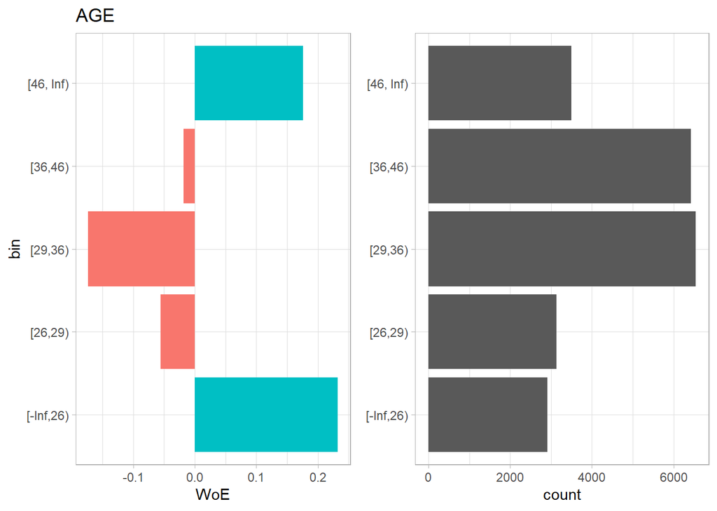

### PAY_0

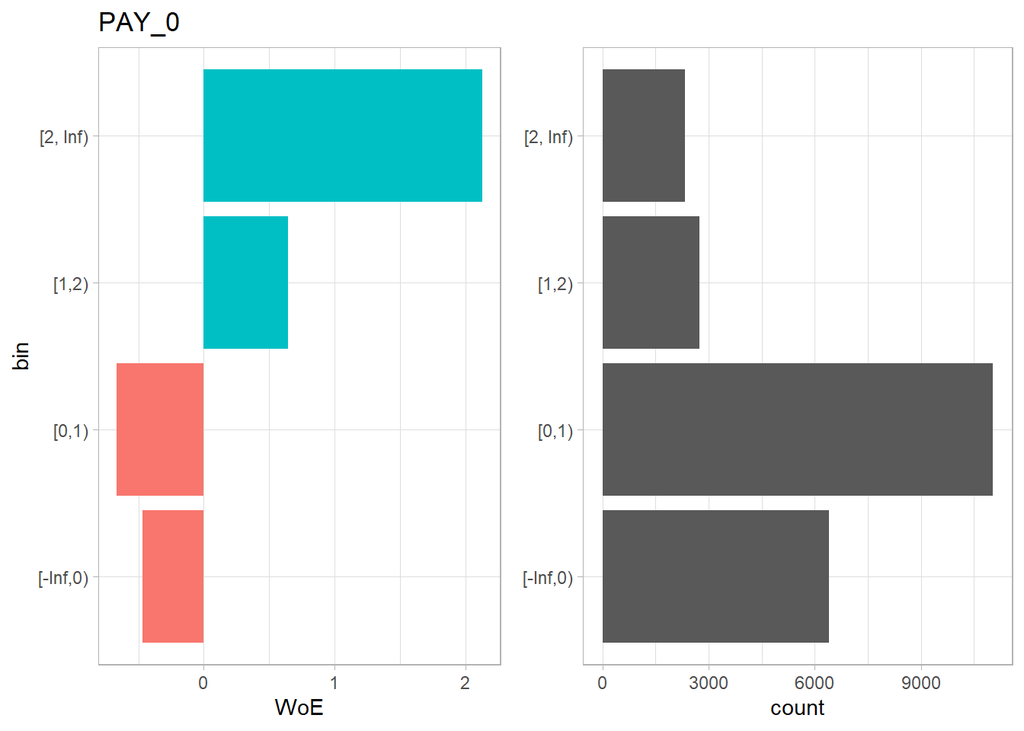

### PAY_2

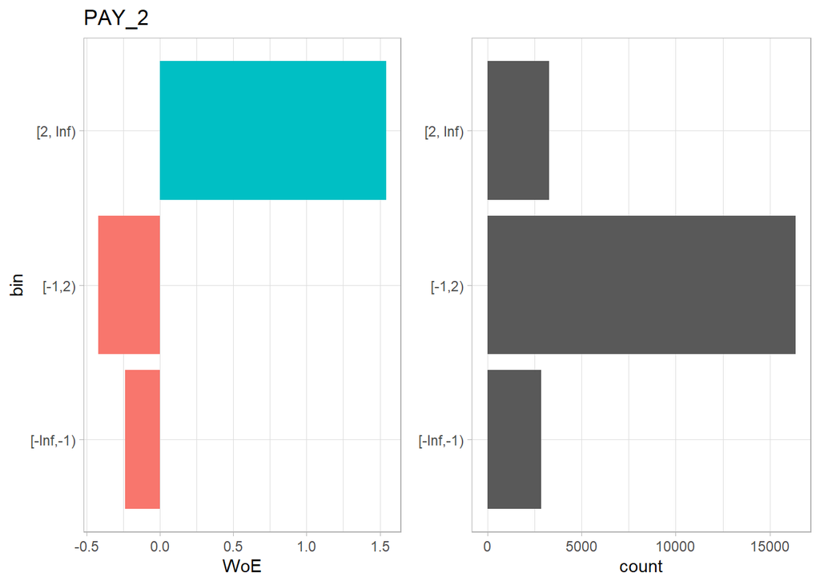

### PAY_4

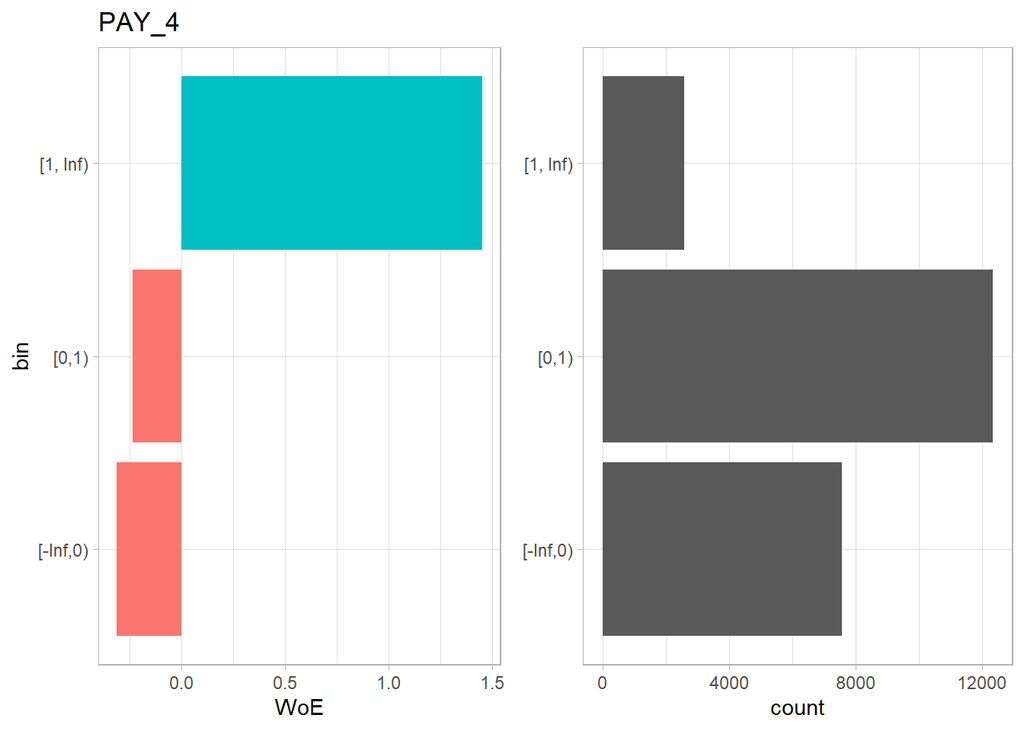